# Introduction

In this series you’ll build an advanced tactical space combat demo inspired by Faster Than Light.

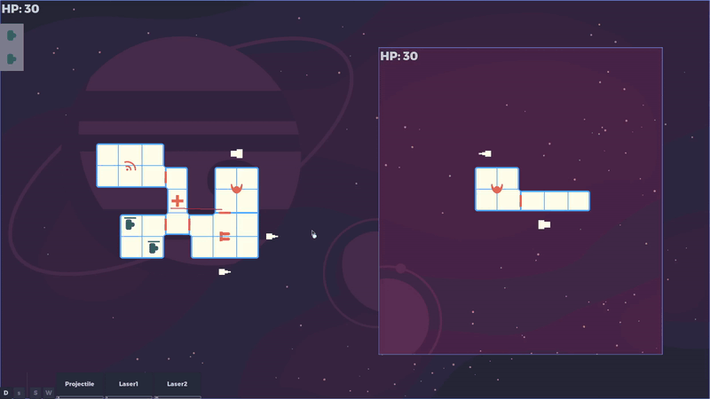

I’m Răzvan Rădulescu also knowns as razcore-rad online. I’m a co-author of PCG Secrets and many more GDQuest projects. I’ll be your instructor for this tutorial course.

## Prerequisites

This series is for advanced developers.

You need to be comfortable with using the Godot editor and programming. I won’t explain every detail, such as assigning resources in the *Inspector* or assigning nodes to groups.

Instead, I’ll focus on teaching you the key techniques and features I used to complete this project.

## What you’ll learn

In this series, you’ll learn about:

- Efficient ways to use the

[figure not shown]

  `TileMap` node to build customizable ships by taking advantage of built-in nodes like the

[figure not shown]

  `CollisionShape2D` and their associated resources.
- Handling unit path movement per room instead of the standard per tile approach you find in most games.
- Managing a modifier mechanic that changes gameplay parameters, such as ship evasion chance and more.
- A modular weapons system that allows for easy customization and extension. We’ll build two types of weapons: projectile and laser-based. We’ll design the system for easy extensibility.
- A flexible approach to UI that lowers code complexity.
- Using viewports to create independent scene hierarchies. One for the player ship and one for the AI ship.

And much more. We’ll also see how to implement hazards like breaches that deplete the room’s oxygen or fire that spreads to neighboring cells.

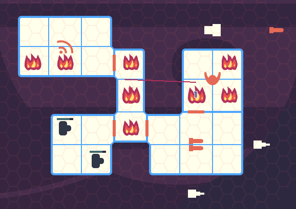

I built this series from the start to take advantage of Godot’s built-in functionality without any other extra OOP abstractions in mind.

This is my little “rebellion” against some established views in OOP that revolve around excessive use of design patterns and principles.

While abstractions are indeed a valuable tool in managing complexity, they can lead to more problems than solutions if used carelessly.

Godot offers us many features to keep our code simple, so my approach to this project is to rely on Godot’s built-in functionality as much as possible and avoid coming up with custom-made solutions.

This tactical demo is a unique project that requires specific solutions that aren’t always easy to generalize.

For instance, the way you can see both ships in a picture-in-picture setting requires the use of viewports and communication between nodes across those viewports. It’s a challenge in itself.

## The start project

The project folder includes a `start-project/` sub-folder for you to start from.

It’s a skeleton Godot project with all the folders and assets we’ll need to make smooth progress.

We also provide all the necessary visual assets in a sub-folder called - you guessed it - `Assets/`.

Here’s the start project’s folder structure:

```
start-project/
├── addons
│   └── ColorPickerPresets
└── TacticalSpaceCombat
    ├── Assets
    ├── Ship
    │   ├── Hazards
    │   ├── Rooms
    │   ├── Units
    │   └── Weapons
    └── UI
```

All our code will live in the `TacticalSpaceCombat/` folder.

The `Ship/` folder will contain all the code related to the ships, be it their shields, AI for units and enemy ships, weapons, rooms, and automated doors.

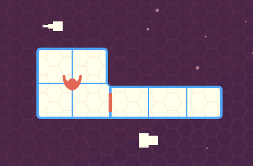

The `UI/` directory will hold every UI element that lives around the screen, like the weapon buttons or unit selection buttons.

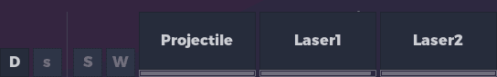

We’ll also have some elements as part of the game world, like the outline that appears around rooms when we hover over them.

It makes the most sense to have those part of the room as they directly hug them.

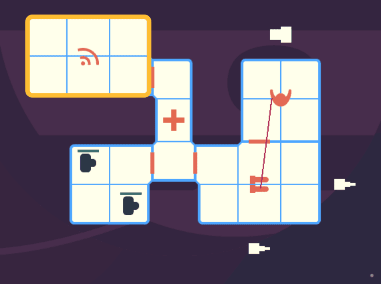

## The included color picker addon

You have one addon included, ColorPickerPresets.

It adds a color palette to the editor’s color pickers to help us pick nice and consistent colors throughout the project. I included the [Pear36](https://lospec.com/palette-list/pear36) palette in this project.

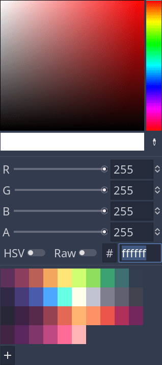

**Warning**: the addon replaces your presets in every color picker. This happens whenever you open the project or enable the addon.

If you want to disable the addon, go to *Project -> Project Settings… -> Plugins*.

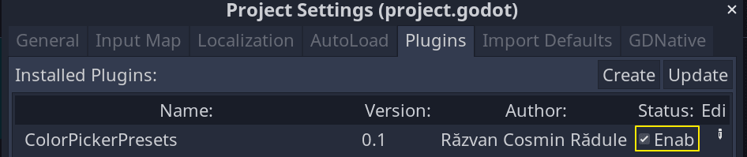